# Lab02 name: Yixuan Li; UPI:Yil845

## 7, Explore data from json dataframe

### How many different days are in the data set? two

```r
unique(geoJson$startDate)
```

```
## [1] 1.514765e+12 1.546301e+12
```

### How many different sites?

```r
length(unique(geoJson$siteID))
```

```
## [1] 509
```

### How are the counts distributed? It is a positive skewed distribution.

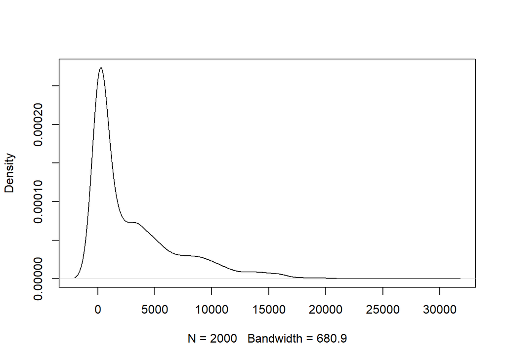

```r
plot(density(geoJson$trafficCount), main="")
```

### create a new column of scount which is the square-root of the counts. The distribution of scount shows several fluctuations and plateau, with a peak at ~10.

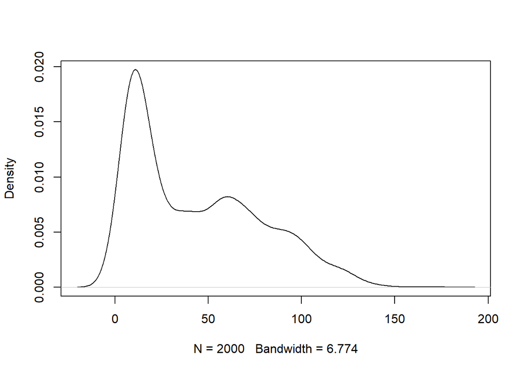

```r
geoJson$scount<-sqrt(geoJson$trafficCount)
plot(density(geoJson$scount), main="")
```

### subset data into light and heavy vehicles respectively

```r
geoJsonH<-subset(geoJson,geoJson$classWeight == "Heavy")
geoJsonL<-subset(geoJson,geoJson$classWeight == "Light")
```

## Transform

### 8,Create a new variable **scount** which contains the square-root of the counts.Because large variation of siteID, we also create a new variable for **ssiteID**

```r
geoJson$scount<-sqrt(geoJson$trafficCount)
geoJson$ssiteID<-sqrt(geoJson$siteID)
```

## Model

### 9, split data into training (90%) and test (10%) sets

```r
index <- sample(rep(1:10, length.out=nrow(geoJson)))
train <- geoJson[index > 1, ]
test <- geoJson[index == 1, ]
```

### fit two models using the training data; one that predicts scount from the overall mean of scount and one that predicts scount from class.

```r
obs <- test$scount
predMean <- mean(train$scount)
lmfit <- lm(scount ~ classWeight, train)
predLM <- predict(lmfit, test)
```

### Calculate the RMSE for both models using the test data

```r
RMSE <- function(obs, pred) {
    sqrt(mean((obs - pred)^2))
}
RMSE(obs,predMean)
```

```
## [1] 32.2264
```

```r
RMSE(obs,predLM)
```

```
## [1] 19.3417
```

### fit a model including siteID as a predictor

```r
lmfit_site <- lm(scount ~ classWeight+ssiteID, train)
predLM_site <- predict(lmfit_site, test)

RMSE(obs,predMean)
```

```
## [1] 32.2264
```

```r
RMSE(obs,predLM_site)
```

```
## [1] 19.3654
```